# Why Do Employees Leave?

Minesh Patel

16 September 2014

### Prerequisite Libraries

```r
library(ggplot2)
```

## Summary

This is an investigation into possible predictor variables to indicate whether or not an employee is likely to leave the organisation. The investigation uses a sample dataset originally from the Oracle Vision EBS database. This has then been pre-processed using Oracle BI Applications HR module (version 7.9.6.4). The methodology used in this investigation can be reproduced on any OBIA HR dataset and ideally will be modified based on the outcomes.

The investigation concludes that the most statistically significant predictors (out of the limited predictors tested) are:

- Years in Service
- Age
- Weekly Hours

The stastitical significance and amplitude of the expected effects are detailed later, in the Results section.

## Exploratory Analysis

Firstly, the data was loaded. In this case, a CSV extract was used. The SQL for the extract is found in Appendix 1. This could be extracted directly from the the Oracle database using ORE.

```r
hrData <- read.csv("HR_Extract_Emp.csv")
```

Additionally, some data tidying is done:

- Converting salary into £k
- Removing employee records with anomalously high salaries
- Converting length of service into years
- Normalise variables

```r
hrData$SALARY <- hrData$SALARY/1000
hrData <- hrData[which(hrData$SALARY < 2000),]
hrData$SERVICE_YEARS <- round(hrData$SERVICE_DAYS/365,2)
hrData$WEEKLY_HOURS <- hrData$HOURS
hrData <- hrData[which(!is.na(hrData$WEEKLY_HOURS)),]

hrData$SALARYn <- (hrData$SALARY - mean(hrData$SALARY))/sd(hrData$SALARY)
hrData$AGEn <- (hrData$AGE - mean(hrData$AGE))/sd(hrData$AGE)
hrData$WEEKLY_HOURSn <- (hrData$WEEKLY_HOURS - mean(hrData$WEEKLY_HOURS))/sd(hrData$WEEKLY_HOURS)
hrData$SERVICE_YEARSn <- (hrData$SERVICE_YEARS - mean(hrData$SERVICE_YEARS))/sd(hrData$SERVICE_YEARS)
```

Then a logistic regression model was applied using all normalised variables:

- Salary
- Years of Service
- Age
- Weekly Hours

```r
model0 <- glm(LEAVE_FLAG ~ SALARYn +
                      SERVICE_YEARSn +
                      AGEn +
                      WEEKLY_HOURSn, data = hrData, family = "binomial")
rawCoefs0 <- summary(model0)$coefficients
expCoefs0 <- exp(model0$coefficients)

print(rawCoefs0)
```

```
##                Estimate Std. Error  z value   Pr(>|z|)
## (Intercept)    -3.48904    0.13898 -25.1038 4.525e-139
## SALARYn         0.07465    0.07947   0.9393  3.476e-01
## SERVICE_YEARSn -4.83770    0.15294 -31.6322 1.331e-219
## AGEn           -0.34295    0.06299  -5.4448  5.187e-08
## WEEKLY_HOURSn  -0.16040    0.08350  -1.9210  5.474e-02
```

The z-test coefficients are compared to a p < 0.1 threshold, deemed suitable for this study. Only salary has a p value outside of this range with: **0.348**. Additionally, the (exponential of) the estimated gradient is: **1.08**, very close to 1. For these reasons it will be excluded from the rest of the study.

Below is the model applied again, with salary removed.

```r
model1 <- glm(LEAVE_FLAG ~
                      SERVICE_YEARSn +
                      AGEn +
                      WEEKLY_HOURSn, data = hrData, family = "binomial")
rawCoefs1 <- summary(model1)$coefficients
print(rawCoefs1)
```

```
##                Estimate Std. Error z value   Pr(>|z|)
## (Intercept)     -3.4974    0.13875 -25.207 3.339e-140
## SERVICE_YEARSn  -4.8337    0.15271 -31.653 6.834e-220
## AGEn            -0.3548    0.06179  -5.741  9.404e-09
## WEEKLY_HOURSn   -0.1449    0.08166  -1.775  7.598e-02
```

```r
expCoefs1 <- exp(model1$coefficients)
print(expCoefs1)
```

```
##    (Intercept) SERVICE_YEARSn           AGEn  WEEKLY_HOURSn
##       0.030276       0.007957       0.701345       0.865107
```

```r
confInts1 <- exp(confint(model1))
print(confInts1)
```

```
##                   2.5 %  97.5 %
## (Intercept)    0.022867 0.03940
## SERVICE_YEARSn 0.005846 0.01064
## AGEn           0.620769 0.79099
## WEEKLY_HOURSn  0.738403 1.01532
```

## Results

As the variables have all been normalised, interpreting the coefficients can be difficult. The model will be run against the original variables for purely this purpose.

```r
model2 <- glm(LEAVE_FLAG ~
                      SERVICE_YEARS +
                      AGE +
                      WEEKLY_HOURS, data = hrData, family = "binomial")
rawCoefs2 <- summary(model2)$coefficients
expCoefs2 <- exp(model2$coefficients)
confInts2 <- exp(confint(model2))
```

We can interpret the coefficients of this model to mean the following:

- For each additional year in service, the employee is **57.9 $\pm$ 2.3% less** likely to leave.
- For every year older, the employee is **4.17 $\pm$ 1.4% less** likely to leave.
- For every additional weekly hour, the employee is **0.918 $\pm$ 0.99% less** likely to leave.

Additionally, the probability of an employee leaving, based on this parameters, is given by:

$P(x_1, x_2, x_3)=P_L=\frac{e^\gamma}{1 + e^\gamma} \\$ $\begin{align} \gamma & =\beta_0 + \beta_1 x_1 + \beta_2 x_2 + \beta_3 x_3 \\ & =-3.5 + -4.8 x_1 + -0.35 x_2 + -0.14 x_3 \end{align}$

where $x_1$ is years of service, $x_2$ is age and $x_3$ is the employee’s weekly hours.

### Plot

Below is a plot showing the fit against the observed values.

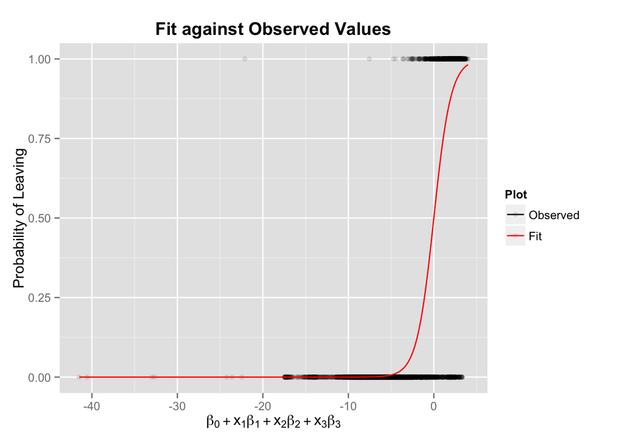

```r
beta0 <- summary(model1)$coefficients[1]
beta1 <- summary(model1)$coefficients[2]
beta2 <- summary(model1)$coefficients[3]
beta3 <- summary(model1)$coefficients[4]

x1 <- hrData$SERVICE_YEARSn
x2 <- hrData$AGEn
x3 <- hrData$WEEKLY_HOURSn

gamma <- beta0 + beta1*x1 + beta2*x2 + beta3*x3

y_fit <- exp(gamma) / (1 + exp(gamma))
y_obs <- hrData$LEAVE_FLAG

plotDF <- data.frame(gamma = gamma, y_obs = y_obs, y_fit = y_fit)
g <-  ggplot() +
      geom_point(data = plotDF, aes(x = gamma, y = y_obs, col = "1"),
                 alpha = 0.1) +
      geom_line(data = plotDF, aes(x = gamma, y = y_fit, col = "2")) +
      labs(title=expression(bold("Fit against Observed Values")),
           x=expression(beta[0]+x[1]*beta[1]+x[2]*beta[2]+x[3]*beta[3]),
           y="Probability of Leaving") +
      scale_colour_manual(name = "Plot",
                          values =c('black', 'red'),
                          labels = c('Observed', 'Fit'))
plot(g)
```

### Prediction Results

The graph above doesn’t immediately indicate the effectiveness of the model. The following compares the effectiveness of the model for employees with $P_L > 0.9$

```r
hrData$P_Leave <- y_fit

p90 <- sum(hrData[which(hrData$P_Leave >= 0.9), "LEAVE_FLAG"])/
      length(hrData[which(hrData$P_Leave >= 0.9), "LEAVE_FLAG"]) * 100
p70 <- sum(hrData[which(hrData$P_Leave >= 0.7), "LEAVE_FLAG"])/
      length(hrData[which(hrData$P_Leave >= 0.7), "LEAVE_FLAG"]) * 100
```

Out of employees with a predicted leave likelihood of 0.9 or greater, **92.4%** did in fact leave. Similarly, **88.6%** left out of the group taken for 0.7 or higher. This suggests that our model works well at high values of $P_L$ but is underestimating the probability as $P_L$ comes down.

## Appendix

### 1 - SQL for data extract

```
select
MAX(Dayd.CALENDAR_DATE) AS CAL_DATE,
MAX(Emp.FULL_NAME) AS FULL_NAME,
Emp.INTEGRATION_ID AS EMP_NUM,
MAX(Wkfc.SALARY_ANNL) AS SALARY,
MAX(CURRENT_SERVICE_DAYS) AS SERVICE_DAYS,
MAX(EMP_POW_BAND_DESC) AS PERIOD_OF_WORK_BAND,
MAX(ROUND(AGE_IN_MONTHS/12,0)) AS AGE,
MAX(AGE_BAND_DESC) AS AGE_BAND,
MAX(Wkfc.TERM_EVENT_IND) AS LEAVE_FLAG,
MAX(STD_HOURS_MONTH) AS HOURS,
MAX(Dayd.CALENDAR_DATE - JOB_ENTRY_DT) AS DAYS_IN_JOB,
MAX(Dayd.CALENDAR_DATE - POS_ENTRY_DT) AS DAYS_IN_POS,
MAX(Dayd.CALENDAR_DATE - ORG_ENTRY_DT) AS DAYS_IN_ORG
from
W_WRKFC_EVT_MONTH_F Wkfc,
W_EMPLOYEE_D Emp,
W_DAY_D Dayd,
W_AGE_BAND_D Age_Band,
W_PRD_OF_WRK_BAND_D Period_Wrk
WHERE
Wkfc.EMPLOYEE_WID = Emp.ROW_WID AND
TRUNC(Wkfc.EFFECTIVE_START_DATE) = TRUNC(Dayd.CALENDAR_DATE) AND
Wkfc.AGE_BAND_WID = Age_Band.ROW_WID AND
Wkfc.PRD_OF_WRK_BAND_WID = Period_Wrk.ROW_WID AND
Dayd.CAL_YEAR BETWEEN 2001 AND 2009
GROUP BY
Dayd.CAL_YEAR,
Emp.INTEGRATION_ID
ORDER BY
Emp.INTEGRATION_ID;
```